# The Movie Database

## Contents

- 1. Introduction
- 2. Data Wrangling
- 3. Exploratory Data Analysis
- 4. Conclusion

## 1. Introduction

The film industry as we know it today emanated in the early 19th century and went through a series of technical developments: the creation of photography, the revelation of the illusion of motion, and the study of human and animal locomotion. After this development, the idea of the motion picture as an entertainment industry first emerged. Since then, the industry has seen phenomenal transformations, some driven by artistic visions, some by commercial necessity, and others by accident. The history of the cinema is complex and rich. During this project, a movie dataset that contains metadata for all 45,000 movies listed in the Full MovieLens Dataset for movies released on or before July 2017. Data points include cast, crew, plot keywords, budget, revenue, posters, release dates, languages, production companies, countries, TMDB vote counts and vote averages will be wrangled and analyzed visually, then presented in explanatory visualizations. You can check the Dataset on Kaggle from [here](https://www.kaggle.com/rounakbanik/the-movies-dataset?select=movies_metadata.csv).

### Motivation

Inspired by my passion for art and cinema, and my enthusiasm for data analysis, I decided to tackle the topic of movies as an EDA (Exploratory Data Analysis) project, focusing on my data visualization skills. I want to discover insights related to cinema from the social and cultural perspectives. So in this notebook, I will try to explore the dataset and find intriguing trends and patterns.

### Dataset Dictionary

- **adult**: Indicates if the movie is X-Rated or Adult.
- **belongs_to_collection**: A stringified dictionary that gives information on the movie series the particular film belongs to.
- **budget**: The budget of the movie in dollars.
- **genres**: A stringified list of dictionaries that list out all the genres associated with the movie.
- **homepage**: The Official Homepage of the move.
- **id**: The ID of the move.
- **imdb_id**: The IMDB ID of the movie.
- **original_language**: The language in which the movie was originally shot in.
- **original_title**: The original title of the movie.
- **overview**: A brief blurb of the movie.
- **popularity**: The Popularity Score assigned by TMDB. Learn more about how it's calculated [here](https://developers.themoviedb.org/3/getting-started/popularity).
- **poster_path**: The URL of the poster image.
- **production_companies**: A stringified list of production companies involved with the making of the movie.
- **production_countries**: A stringified list of countries where the movie was shot/produced in.
- **release_date**: Theatrical Release Date of the movie.
- **revenue**: The total revenue of the movie in dollars.
- **runtime**: The runtime of the movie in minutes.
- **spoken_languages**: A stringified list of spoken languages in the film.
- **status**: The status of the movie (Released, To Be Released, Announced, etc.)
- **tagline**: The tagline of the movie.
- **title**: The Official Title of the movie.
- **video**: Indicates if there is a video present of the movie with TMDB.
- **vote_average**: The average rating of the movie.
- **vote_count**: The number of votes by users, as counted by TMDB.
- **cast**: A stringified list of dictionaries consisting of cast names and the corresponding characters they played.
- **crew**: A stringified list of dictionaries consisting of crew names and the function they performed.

### Dataset Structure

The whole dataset is one observational unit representing movies data. Each row represents 1 movie and the data related to it, while each column represents different movie features, such as *movie title, original language* and *production countries*.

#### Main Features of Interest

This analysis is very exploratory, meaning that there are no specific questions of interest. The main focus is to discover new patterns in the cinematic world. I'm mostly interested in social findings, so my concentration will be centered at observing features like *original language* over time. So *year released* will definitely be a crucial feature for the analysis. Plus additional core features will be engineered later like *director's gender*.

#### Supporting Features

There are many useful supporting features, such as *genre, spoken languages, runtime, vote average* and *vote count*.

### Final Notes

- There are 2 variables that seem significant *budget & revenue* that won't be main features due to many reasons, of which:
  - Marketing expenses aren't added to the movie announced budget which is misleading.
  - I'm interested in intercultural observations more than commercial success observations.
  - Lastly, cinema is an art that unfortunately depends on money, but it's still an art, so I'd like to tackle it with appreciation.
- Some additional features may be engineered or added later on according to the investigation process needs.

## 2. Data Wrangling

- 1.1. Data Gathering
- 1.2. Data Assessment
- 1.3. Data Cleaning
- 1.4. Data Engineering

### 1.1. Data Gathering

Data was manually downloaded from Kaggle.

```python
# Import all needed packages
import numpy as np
import pandas as pd
import matplotlib.pyplot as plt
import seaborn as sb
from IPython.display import Image, HTML
import json
import datetime
import ast
from wordcloud import WordCloud, STOPWORDS
import iso639
from iso639 import languages
from PIL import Image

# Set plots to be embedded inline
%matplotlib inline
```

```python
# Import the meta data CSV file as a Pandas dataframe
meta = pd.read_csv('movies_metadata.csv')
# Make sure it was imported successfully
meta.head()
```

|  | adult | belongs_to_collection | budget | genres | homepage | id | imdb_id | original_language | original_title | overview | ... | release_date | revenue | runtime | spoken_languages | status | tagline | title | video | vote_average | vote_count |
| --- | --- | --- | --- | --- | --- | --- | --- | --- | --- | --- | --- | --- | --- | --- | --- | --- | --- | --- | --- | --- | --- |
| 0 | False | {'id': 10194, 'name': 'Toy Story Collection', ... | 30000000 | [{'id': 16, 'name': 'Animation'}, {'id': 35, '... | http://toystory.disney.com/toy-story | 862 | tt0114709 | en | Toy Story | Led by Woody, Andy's toys live happily in his ... | ... | 1995-10-30 | 373554033.0 | 81.0 | [{'iso_639_1': 'en', 'name': 'English'}] | Released | NaN | Toy Story | False | 7.7 | 5415.0 |
| 1 | False | NaN | 65000000 | [{'id': 12, 'name': 'Adventure'}, {'id': 14, '... | NaN | 8844 | tt0113497 | en | Jumanji | When siblings Judy and Peter discover an encha... | ... | 1995-12-15 | 262797249.0 | 104.0 | [{'iso_639_1': 'en', 'name': 'English'}, {'iso... | Released | Roll the dice and unleash the excitement! | Jumanji | False | 6.9 | 2413.0 |
| 2 | False | {'id': 119050, 'name': 'Grumpy Old Men Collect... | 0 | [{'id': 10749, 'name': 'Romance'}, {'id': 35, ... | NaN | 15602 | tt0113228 | en | Grumpier Old Men | A family wedding reignites the ancient feud be... | ... | 1995-12-22 | 0.0 | 101.0 | [{'iso_639_1': 'en', 'name': 'English'}] | Released | Still Yelling. Still Fighting. Still Ready for... | Grumpier Old Men | False | 6.5 | 92.0 |
| 3 | False | NaN | 16000000 | [{'id': 35, 'name': 'Comedy'}, {'id': 18, 'nam... | NaN | 31357 | tt0114885 | en | Waiting to Exhale | Cheated on, mistreated and stepped on, the wom... | ... | 1995-12-22 | 81452156.0 | 127.0 | [{'iso_639_1': 'en', 'name': 'English'}] | Released | Friends are the people who let you be yourself... | Waiting to Exhale | False | 6.1 | 34.0 |
| 4 | False | {'id': 96871, 'name': 'Father of the Bride Col... | 0 | [{'id': 35, 'name': 'Comedy'}] | NaN | 11862 | tt0113041 | en | Father of the Bride Part II | Just when George Banks has recovered from his ... | ... | 1995-02-10 | 76578911.0 | 106.0 | [{'iso_639_1': 'en', 'name': 'English'}] | Released | Just When His World Is Back To Normal... He's ... | Father of the Bride Part II | False | 5.7 | 173.0 |

5 rows × 24 columns

```python
# Import the crew CSV file
crew = pd.read_csv('credits.csv')
crew.head()
```

|  | cast | crew | id |
| --- | --- | --- | --- |
| 0 | [{'cast_id': 14, 'character': 'Woody (voice)',... | [{'credit_id': '52fe4284c3a36847f8024f49', 'de... | 862 |
| 1 | [{'cast_id': 1, 'character': 'Alan Parrish', '... | [{'credit_id': '52fe44bfc3a36847f80a7cd1', 'de... | 8844 |
| 2 | [{'cast_id': 2, 'character': 'Max Goldman', 'c... | [{'credit_id': '52fe466a9251416c75077a89', 'de... | 15602 |
| 3 | [{'cast_id': 1, 'character': "Savannah 'Vannah... | [{'credit_id': '52fe44779251416c91011acb', 'de... | 31357 |
| 4 | [{'cast_id': 1, 'character': 'George Banks', '... | [{'credit_id': '52fe44959251416c75039ed7', 'de... | 11862 |

### 1.2. Data Assessment

In this step data will be assessed to observe what needs to be changed or cleaned.

```python
# Take a look on our data
meta.info()
```

```
<class 'pandas.core.frame.DataFrame'>
RangeIndex: 45466 entries, 0 to 45465
Data columns (total 24 columns):
 #   Column                 Non-Null Count  Dtype
---  ------                 --------------  -----
 0   adult                  45466 non-null  object
 1   belongs_to_collection  4494 non-null   object
 2   budget                 45466 non-null  object
 3   genres                 45466 non-null  object
 4   homepage               7782 non-null   object
 5   id                     45466 non-null  object
 6   imdb_id                45449 non-null  object
 7   original_language      45455 non-null  object
 8   original_title         45466 non-null  object
 9   overview               44512 non-null  object
```

[output cut: 16 more lines]

```python
meta['belongs_to_collection']
```

```
0        {'id': 10194, 'name': 'Toy Story Collection', ...
1                                                      NaN
2        {'id': 119050, 'name': 'Grumpy Old Men Collect...
3                                                      NaN
4        {'id': 96871, 'name': 'Father of the Bride Col...
                               ...
45461                                                  NaN
45462                                                  NaN
45463                                                  NaN
45464                                                  NaN
45465                                                  NaN
Name: belongs_to_collection, Length: 45466, dtype: object
```

```python
meta['production_companies']
```

```
0           [{'name': 'Pixar Animation Studios', 'id': 3}]
1        [{'name': 'TriStar Pictures', 'id': 559}, {'na...
2        [{'name': 'Warner Bros.', 'id': 6194}, {'name'...
3        [{'name': 'Twentieth Century Fox Film Corporat...
4        [{'name': 'Sandollar Productions', 'id': 5842}...
                               ...
45461                                                   []
45462               [{'name': 'Sine Olivia', 'id': 19653}]
45463    [{'name': 'American World Pictures', 'id': 6165}]
45464                 [{'name': 'Yermoliev', 'id': 88753}]
45465                                                   []
Name: production_companies, Length: 45466, dtype: object
```

```python
# Visual assessment may be useful for columns with long text
crew.cast[0]
```

```
"[{'cast_id': 14, 'character': 'Woody (voice)', 'credit_id': '52fe4284c3a36847f8024f95', 'gender': 2, 'id': 31, 'name': 'Tom Hanks', 'order': 0, 'profile_path': '/pQFoyx7rp09CJTAb932F2g8Nlho.jpg'}, {'cast_id': 15, 'character': 'Buzz Lightyear (voice)', 'credit_id': '52fe4284c3a36847f8024f99', 'gende…
```

```python
crew.crew[25]
```

```
"[{'credit_id': '5462510ec3a368082d000121', 'department': 'Writing', 'gender': 2, 'id': 6210, 'job': 'Writer', 'name': 'William Shakespeare', 'profile_path': '/2z4njqosEQM4g26ttb9grG9rJUg.jpg'}, {'credit_id': '52fe46d29251416c75084b07', 'department': 'Directing', 'gender': 2, 'id': 56710, 'job': 'Di…
```

As for crew and cast, it appears that the key `gender` means the following:

- Female if assigned 1.
- Male if assigned 2.
- Not sure if assigned 0.

This may help during the engineering process.

### Quality Issues

- It appears that some columns have a lot of missing values like `belongs_to_collection`, `homepage` and `tagline`. We don't need them in our analysis anyway so we may safely drop them. However the first one should be deleted only after deleting its corresponding movies aka Franchise movies.
- There also seem to be some columns with the wrong data type like `release_date` that should be in datetime format, `budget` that should be numeric, and `adult` that should be bool.
- So these columns `adult`, `homepage`, `imdb_id`, `tagline` and `video` are simply not needed for our analysis.

### Tidiness Issues

- We need to create new features that will be used in our analysis like `year`, `director`, `writer`
- We need to merge both dataframes `meta` and `crew` since both form one observational unit.

Let's dig deeper beyond visual assessment.

```python
crew.info()
```

```
<class 'pandas.core.frame.DataFrame'>
RangeIndex: 45476 entries, 0 to 45475
Data columns (total 3 columns):
 #   Column  Non-Null Count  Dtype
---  ------  --------------  -----
 0   cast    45476 non-null  object
 1   crew    45476 non-null  object
 2   id      45476 non-null  int64
dtypes: int64(1), object(2)
memory usage: 1.0+ MB
```

```python
meta.info()
```

[output not shown]

[output cut: 16 more lines]

```python
meta.id.duplicated().sum()
```

```
30
```

```python
crew.id.duplicated().sum()
```

```
44
```

The attribute **id** should be a unique identifier for the movie, so we must delete duplicates.

```python
meta['popularity'].value_counts()
```

```
0.0         34
0.0         32
1e-06       30
0.000844    26
1e-06       26
            ..
0.100611     1
1.974792     1
2.772269     1
0.071781     1
0.105753     1
Name: popularity, Length: 44176, dtype: int64
```

Looking at it, popularity should be a numeric feature.

```python
meta['status'].value_counts()
```

```
Released           45014
Rumored              230
Post Production       98
In Production         20
Planned               15
Canceled               2
Name: status, dtype: int64
```

```python
meta[meta['status'] == 'Rumored']
```

[output not shown]

Only released movies matter for our analysis.

```python
meta[meta['original_title'] != meta['title']][['title', 'original_title']].sample(5)
```

|  | title | original_title |
| --- | --- | --- |
| 31442 | Hunger | La Faim |
| 44439 | Intergirl | Interdevochka |
| 31807 | The Hired Gun | Vai Gorilla |
| 31943 | Gothic & Lolita Psycho | Gosurori shokeinin |
| 30382 | The Girl from Parma | La Parmigiana |

Interesting! Looks like original title represents the movie name in its original language. This can be useful for an intercultural wordcloud visualization, so I won't drop it.

```python
meta[meta['revenue'] == 0].shape
```

```
(38052, 24)
```

```python
meta['budget'] = pd.to_numeric(meta['budget'], errors='coerce')
meta[meta['budget'] == 0].shape
```

```
(36573, 24)
```

```python
meta[meta['budget'] == 0].shape[0] / len(meta.budget)
```

```
0.8044032903708266
```

Looks like there are many missing values for revenue and budget data that consists almost 80% of our whole observations. Since our analysis isn't interested in commercial return of cinema, we may safely drop them.

```python
meta['original_language'].value_counts()
```

```
en      32269
fr       2438
it       1529
ja       1350
de       1080
        ...
82.0        1
gl          1
jv          1
68.0        1
rw          1
Name: original_language, Length: 92, dtype: int64
```

It seems like there are some inaccurate values in this column, so we will need to delete them if their percentage among other accurate values isn't significant.

```python
meta[meta.original_language.str.count('\d') != 0]
```

|  | adult | belongs_to_collection | budget | genres | homepage | id | imdb_id | original_language | original_title | overview | ... | release_date | revenue | runtime | spoken_languages | status | tagline | title | video | vote_average | vote_count |
| --- | --- | --- | --- | --- | --- | --- | --- | --- | --- | --- | --- | --- | --- | --- | --- | --- | --- | --- | --- | --- | --- |
| 19574 | False | NaN | 0 | [{'id': 99, 'name': 'Documentary'}] | NaN | 283101 | tt0429086 | NaN | Shadowing the Third Man | Documentary about the production of The Third ... | ... | 2004-10-11 | 0.0 | 95.0 | [{'iso_639_1': 'de', 'name': 'Deutsch'}, {'iso... | Released | NaN | Shadowing the Third Man | False | 0.0 | 0.0 |
| 19730 | - Written by Ørnås | 0.065736 | /ff9qCepilowshEtG2GYWwzt2bs4.jpg | [{'name': 'Carousel Productions', 'id': 11176}... | [{'iso_3166_1': 'CA', 'name': 'Canada'}, {'iso... | 1997-08-20 | 0 | 104.0 | [{'iso_639_1': 'en', 'name': 'English'}] | Released | ... | 1 | NaN | NaN | NaN | NaN | NaN | NaN | NaN | NaN | NaN |
| 21602 | False | NaN | 0 | [{'id': 10749, 'name': 'Romance'}, {'id': 18, ... | NaN | 103902 | tt0838231 | NaN | Unfinished Sky | An Outback farmer takes in an Afghani woman wh... | ... | 2007-08-04 | 0.0 | 94.0 | [{'iso_639_1': 'en', 'name': 'English'}] | Released | NaN | Unfinished Sky | False | 6.4 | 8.0 |
| 22832 | False | NaN | 0 | [{'id': 10752, 'name': 'War'}, {'id': 37, 'nam... | NaN | 359195 | tt0053558 | NaN | 13 Fighting Men | A group of Union Army soldiers is charged with... | ... | 1960-03-31 | 0.0 | 69.0 | [{'iso_639_1': 'en', 'name': 'English'}] | Released | NaN | 13 Fighting Men | False | 0.0 | 0.0 |
| 29503 | Rune Balot goes to a casino connected to the ... | 1.931659 | /zV8bHuSL6WXoD6FWogP9j4x80bL.jpg | [{'name': 'Aniplex', 'id': 2883}, {'name': 'Go... | [{'iso_3166_1': 'US', 'name': 'United States o... | 2012-09-29 | 0 | 68.0 | [{'iso_639_1': 'ja', 'name': '日本語'}] | Released | ... | 12 | NaN | NaN | NaN | NaN | NaN | NaN | NaN | NaN | NaN |
| 32141 | False | NaN | 0 | [{'id': 35, 'name': 'Comedy'}] | NaN | 147050 | tt0122580 | NaN | Lambchops | George and Gracie enter an elegant drawing roo... | ... | 1929-10-31 | 0.0 | 8.0 | [{'iso_639_1': 'en', 'name': 'English'}] | Released | NaN | Lambchops | False | 6.5 | 2.0 |
| 35587 | Avalanche Sharks tells the story of a bikini ... | 2.185485 | /zaSf5OG7V8X8gqFvly88zDdRm46.jpg | [{'name': 'Odyssey Media', 'id': 17161}, {'nam... | [{'iso_3166_1': 'CA', 'name': 'Canada'}] | 2014-01-01 | 0 | 82.0 | [{'iso_639_1': 'en', 'name': 'English'}] | Released | ... | 22 | NaN | NaN | NaN | NaN | NaN | NaN | NaN | NaN | NaN |
| 37407 | False | NaN | 0 | [{'id': 16, 'name': 'Animation'}] | NaN | 257095 | tt0225145 | NaN | Bajaja | The first fairy tale transformed into a full-l... | ... | 1950-01-26 | 0.0 | 87.0 | [{'iso_639_1': 'cs', 'name': 'Český'}] | Released | NaN | Prince Bayaya | False | 5.0 | 1.0 |
| 41047 | False | NaN | 0 | [{'id': 99, 'name': 'Documentary'}] | NaN | 332742 | tt4432912 | NaN | Song of Lahore | Until the late 1970s, the Pakistani city of La... | ... | 2015-11-13 | 0.0 | 82.0 | [{'iso_639_1': 'ur', 'name': 'اردو'}, {'iso_63... | Released | NaN | Song of Lahore | False | 6.5 | 2.0 |
| 41872 | False | NaN | 0 | [{'id': 99, 'name': 'Documentary'}] | NaN | 144410 | tt0154152 | NaN | Annabelle Serpentine Dance | Two dancers perform in succession facing a sta... | ... | 1895-04-01 | 0.0 | 1.0 | [{'iso_639_1': 'xx', 'name': 'No Language'}] | Released | NaN | Annabelle Serpentine Dance | False | 5.7 | 20.0 |
| 44057 | False | NaN | 0 | [{'id': 18, 'name': 'Drama'}] | NaN | 380438 | tt0298411 | NaN | Lettre d'une inconnue | NaN | ... | 2001-01-01 | 0.0 | 0.0 | [{'iso_639_1': 'fr', 'name': 'Français'}] | Released | NaN | Lettre d'une inconnue | False | 0.0 | 0.0 |
| 44410 | False | NaN | 0 | [{'id': 16, 'name': 'Animation'}, {'id': 99, '... | NaN | 381096 | tt5333518 | NaN | Garn | The traditional crafts of crochet and knitting... | ... | 2016-03-12 | 0.0 | 76.0 | [{'iso_639_1': 'sv', 'name': 'svenska'}, {'iso... | Released | NaN | Yarn | False | 0.0 | 0.0 |
| 44576 | False | NaN | 0 | [] | NaN | 381525 | tt5376720 | NaN | WiNWiN | American investment fund buys Austrian compani... | ... | 2016-01-27 | 0.0 | 84.0 | [{'iso_639_1': 'de', 'name': 'Deutsch'}, {'iso... | Released | NaN | WiNWiN | False | 0.0 | 0.0 |
| 44655 | False | NaN | 0 | [{'id': 28, 'name': 'Action'}, {'id': 10752, '... | NaN | 104473 | tt0223958 | NaN | La prise de Tournavos | Three military men, seen inside a fortificatio... | ... | 1897-01-01 | 0.0 | 1.0 | [{'iso_639_1': 'xx', 'name': 'No Language'}] | Rumored | NaN | The Surrender of Tournavos | False | 4.6 | 5.0 |

14 rows × 24 columns

These rows seem to have many inaccurate values so it's very important to drop them first.

```python
meta['overview'].value_counts()
```

[output not shown]

```python
meta['runtime'].value_counts()
```

[output not shown]

```
90.0     2556
0.0      1558
100.0    1470
95.0     1412
93.0     1214
         ...
705.0       1
338.0       1
551.0       1
299.0       1
501.0       1
Name: runtime, Length: 353, dtype: int64
```

```python
meta[meta.runtime == 0]
```

|  | adult | belongs_to_collection | budget | genres | homepage | id | imdb_id | original_language | original_title | overview | ... | release_date | revenue | runtime | spoken_languages | status | tagline | title | video | vote_average | vote_count |
| --- | --- | --- | --- | --- | --- | --- | --- | --- | --- | --- | --- | --- | --- | --- | --- | --- | --- | --- | --- | --- | --- |
| 222 | False | NaN | 0.0 | [{'id': 53, 'name': 'Thriller'}] | NaN | 61813 | tt0112899 | en | Dream Man | Kris is a homicide cop with psychic abilities.... | ... | 1995-01-01 | 0.0 | 0.0 | [{'iso_639_1': 'en', 'name': 'English'}] | Released | NaN | Dream Man | False | 2.5 | 1.0 |
| 224 | False | NaN | 0.0 | [{'id': 80, 'name': 'Crime'}, {'id': 35, 'name... | NaN | 62488 | tt0112854 | it | Destiny Turns on the Radio | Johnny Destiny burns into Las Vegas in his hot... | ... | 1995-04-28 | 0.0 | 0.0 | [{'iso_639_1': 'en', 'name': 'English'}] | Released | Fate visits in ways you never expect | Destiny Turns on the Radio | False | 5.3 | 9.0 |
| 398 | False | NaN | 0.0 | [] | NaN | 172923 | tt0112889 | en | Dos Crímenes | Greed and playing into the hand of providence ... | ... | 1995-05-26 | 0.0 | 0.0 | [] | Released | NaN | Dos Crímenes | False | 5.0 | 1.0 |
| 554 | False | NaN | 0.0 | [] | NaN | 218473 | tt0109226 | en | The Beans of Egypt, Maine | The Beans are poor, proud, hated by all, but a... | ... | 1994-01-01 | 0.0 | 0.0 | [] | Released | NaN | The Beans of Egypt, Maine | False | 0.0 | 1.0 |
| 667 | False | NaN | 0.0 | [{'id': 18, 'name': 'Drama'}, {'id': 10749, 'n... | NaN | 221917 | tt0114307 | en | The Run of the Country | An Irish lad (Matt Keeslar) who fled from his ... | ... | 1995-09-22 | 0.0 | 0.0 | [{'iso_639_1': 'en', 'name': 'English'}] | Released | An unforgettable romance | The Run of the Country | False | 8.0 | 2.0 |
| ... | ... | ... | ... | ... | ... | ... | ... | ... | ... | ... | ... | ... | ... | ... | ... | ... | ... | ... | ... | ... | ... |
| 45370 | False | NaN | 0.0 | [{'id': 18, 'name': 'Drama'}] | NaN | 374764 | tt3529010 | es | Cómo funcionan casi todas las cosas | Celina works at a remote tollbooth on a desert... | ... | 2015-11-12 | 0.0 | 0.0 | [{'iso_639_1': 'es', 'name': 'Español'}] | Released | NaN | How Most Things Work | False | 6.8 | 2.0 |
| 45371 | False | {'id': 477208, 'name': 'DC Super Hero Girls Co... | 0.0 | [{'id': 16, 'name': 'Animation'}] | NaN | 460135 | tt7158814 | en | LEGO DC Super Hero Girls: Brain Drain | When Supergirl, Wonder Woman, Batgirl, Bumbleb... | ... | 2017-08-30 | 0.0 | 0.0 | [{'iso_639_1': 'en', 'name': 'English'}, {'iso... | Released | NaN | LEGO DC Super Hero Girls: Brain Drain | False | 10.0 | 2.0 |
| 45399 | False | NaN | 750000.0 | [{'id': 80, 'name': 'Crime'}, {'id': 35, 'name... | NaN | 280422 | tt3805180 | ru | Все и сразу | NaN | ... | 2014-06-05 | 3.0 | 0.0 | [{'iso_639_1': 'ru', 'name': 'Pусский'}] | Released | NaN | All at Once | False | 6.0 | 4.0 |
| 45416 | False | NaN | 0.0 | [{'id': 35, 'name': 'Comedy'}] | NaN | 282308 | tt0427767 | en | Rigadin peintre cubiste | After visiting the first Cubist exposition in ... | ... | 1912-01-01 | 0.0 | 0.0 | [{'iso_639_1': 'fr', 'name': 'Français'}] | Released | NaN | Whiffles, Cubic Artist | False | 0.0 | 0.0 |
| 45430 | False | NaN | 0.0 | [{'id': 53, 'name': 'Thriller'}, {'id': 878, '... | NaN | 222872 | tt0120200 | en | Starquest II | Sci-fi thriller directed by Fred Gallo. | ... | 1996-01-01 | 0.0 | 0.0 | [] | Released | NaN | Starquest II | False | 2.0 | 1.0 |

1558 rows × 24 columns

```python
meta[meta.vote_count == 0]
```

|  | adult | belongs_to_collection | budget | genres | homepage | id | imdb_id | original_language | original_title | overview | ... | release_date | revenue | runtime | spoken_languages | status | tagline | title | video | vote_average | vote_count |
| --- | --- | --- | --- | --- | --- | --- | --- | --- | --- | --- | --- | --- | --- | --- | --- | --- | --- | --- | --- | --- | --- |
| 83 | False | NaN | 0.0 | [] | NaN | 188588 | tt0113612 | en | Last Summer in the Hamptons | Filmed entirely on location in East Hampton, L... | ... | 1995-11-22 | 0.0 | 108.0 | [] | Released | NaN | Last Summer in the Hamptons | False | 0.0 | 0.0 |
| 107 | False | NaN | 0.0 | [{'id': 80, 'name': 'Crime'}] | NaN | 96357 | tt0113276 | en | Headless Body in Topless Bar | An ex-con holds a group of people hostage in a... | ... | 1995-05-20 | 0.0 | 110.0 | [] | Released | NaN | Headless Body in Topless Bar | False | 0.0 | 0.0 |
| 126 | False | NaN | 0.0 | [] | NaN | 290157 | tt0110217 | en | Jupiter's Wife | Michel Negroponte, a documentary filmmaker, me... | ... | 1995-01-01 | 0.0 | 87.0 | [] | Released | A Haunting Real Life Mystery | Jupiter's Wife | False | 0.0 | 0.0 |
| 132 | False | NaN | 0.0 | [{'id': 10402, 'name': 'Music'}, {'id': 99, 'n... | NaN | 124636 | tt0114500 | en | Sonic Outlaws | Within days after the release of Negativland's... | ... | 1995-08-01 | 0.0 | 87.0 | [{'iso_639_1': 'en', 'name': 'English'}] | Released | NaN | Sonic Outlaws | False | 0.0 | 0.0 |
| 137 | False | NaN | 0.0 | [] | NaN | 124639 | tt0114618 | en | Target | A subtle yet violent commentary on feudal lords. | ... | 1995-08-01 | 0.0 | 122.0 | [] | Released | NaN | Target | False | 0.0 | 0.0 |
| ... | ... | ... | ... | ... | ... | ... | ... | ... | ... | ... | ... | ... | ... | ... | ... | ... | ... | ... | ... | ... | ... |
| 45432 | False | NaN | 0.0 | [{'id': 99, 'name': 'Documentary'}] | NaN | 323132 | tt0074124 | en | Altar of Fire | This film records a 12 day ritual performed by... | ... | 1976-01-01 | 0.0 | 45.0 | [{'iso_639_1': 'en', 'name': 'English'}] | Released | NaN | Altar of Fire | False | 0.0 | 0.0 |
| 45434 | False | NaN | 0.0 | [] | NaN | 325439 | tt0055178 | en | Le Meraviglie di Aladino | Young Aladdin (Donald O'Connor) has a series o... | ... | 1961-10-31 | 0.0 | 93.0 | [{'iso_639_1': 'en', 'name': 'English'}] | Released | NaN | The Wonders of Aladdin | False | 0.0 | 0.0 |
| 45452 | False | NaN | 0.0 | [{'id': 99, 'name': 'Documentary'}] | NaN | 276895 | tt3054038 | en | Deep Hearts | Deep Hearts is a film about the Bororo Fulani,... | ... | 1981-01-01 | 0.0 | 58.0 | [{'iso_639_1': 'ff', 'name': 'Fulfulde'}, {'is... | Released | NaN | Deep Hearts | False | 0.0 | 0.0 |
| 45464 | False | NaN | 0.0 | [] | NaN | 227506 | tt0008536 | en | Satana likuyushchiy | In a small town live two brothers, one a minis... | ... | 1917-10-21 | 0.0 | 87.0 | [] | Released | NaN | Satan Triumphant | False | 0.0 | 0.0 |
| 45465 | False | NaN | 0.0 | [] | NaN | 461257 | tt6980792 | en | Queerama | 50 years after decriminalisation of homosexual... | ... | 2017-06-09 | 0.0 | 75.0 | [{'iso_639_1': 'en', 'name': 'English'}] | Released | NaN | Queerama | False | 0.0 | 0.0 |

2899 rows × 24 columns

We can drop the rows where movie runtime doesn't exist since they're few compared to our other observations. And movies that have zero vote count since they won't have the rating which is an essential supporting feature.

#### To clean List:

- Merge `meta` and `crew` dataframes together.
- Drop columns: `adult`, `imdb_id`, `homepage`, `video`, `budget`, `revenue` and `tagline` since they are simply not needed in our analysis.
- Drop rows with any status other than *Released* then drop the whole `status` column.
- Drop rows of Franchise movies then delete `belongs_to_collection` column.
- Drop inaccurate rows in `original_language` column.
- Drop inaccurate rowns in `runtime` column.
- Drop rows with zero `vote_count`.
- Convert `release_date` to datetime format.
- Convert `popularity` to float type.

### 1.3. Data Cleaning

```python
# Drop duplicates before merging
meta.id.drop_duplicates(keep = 'first', inplace=True)
crew.id.drop_duplicates(keep = 'first', inplace=True)
```

```python
# Drop inaccurate entries
meta = meta.drop(meta[meta.original_language.str.count('\d') != 0].index)
crew = crew.drop(meta[meta.original_language.str.count('\d') != 0].index)
```

```python
# Convert id in the meta df into integer to match id in the crew df
meta.id = meta.id.astype(int)
```

```python
# Merge the two dataframes into one
movies = meta.merge(crew, on='id')
movies.info()
```

```
<class 'pandas.core.frame.DataFrame'>
Int64Index: 45527 entries, 0 to 45526
Data columns (total 26 columns):
 #   Column                 Non-Null Count  Dtype
---  ------                 --------------  -----
 0   adult                  45527 non-null  object
 1   belongs_to_collection  4500 non-null   object
 2   budget                 45527 non-null  object
 3   genres                 45527 non-null  object
 4   homepage               7792 non-null   object
 5   id                     45527 non-null  int64
 6   imdb_id                45510 non-null  object
 7   original_language      45527 non-null  object
 8   original_title         45527 non-null  object
 9   overview               44574 non-null  object
```

[output cut: 18 more lines]

Looks good so far! Now let's make a copy of our new dataframe before cleaning to avoid data loss.

```python
movies_clean = movies.copy()
```

```python
# Drop attributes we don't need for this project
movies_clean = movies_clean.drop(['imdb_id', 'tagline', 'video', 'homepage', 'adult', 'revenue', 'budget'], axis=1)
```

```python
# Drop movies with a status different than released
movies_clean.drop(movies_clean[movies_clean['status'] != 'Released'].index, inplace=True)

# Drop status column since all are the same status now
movies_clean = movies_clean.drop(['status'], axis=1)
```

```python
# Drop Franchise movies data
franchise = movies_clean[movies_clean['belongs_to_collection'].notnull()]
movies_clean.drop(franchise.index, inplace=True)
```

```python
# Drop Franchise movies column
movies_clean = movies_clean.drop(['belongs_to_collection'], axis=1)
```

```python
# Drop movies with zero runtime and zero vote count
zero_runtime = movies_clean[movies_clean['runtime'] == 0]
movies_clean.drop(zero_runtime.index, inplace=True)

zero_vote = movies_clean[movies_clean['vote_count'] == 0]
movies_clean.drop(zero_vote.index, inplace=True)
```

```python
# Make sure everything looks alright
movies_clean.info()
```

```
<class 'pandas.core.frame.DataFrame'>
Int64Index: 36720 entries, 1 to 45524
Data columns (total 17 columns):
 #   Column                Non-Null Count  Dtype
---  ------                --------------  -----
 0   genres                36720 non-null  object
 1   id                    36720 non-null  int64
 2   original_language     36720 non-null  object
 3   original_title        36720 non-null  object
 4   overview              36350 non-null  object
 5   popularity            36720 non-null  object
 6   poster_path           36636 non-null  object
 7   production_companies  36720 non-null  object
 8   production_countries  36720 non-null  object
 9   release_date          36696 non-null  object
 10  runtime               36572 non-null  float64
 11  spoken_languages      36720 non-null  object
 12  title                 36720 non-null  object
 13  vote_average          36720 non-null  float64
 14  vote_count            36720 non-null  float64
 15  cast                  36720 non-null  object
 16  crew                  36720 non-null  object
dtypes: float64(3), int64(1), object(13)
memory usage: 5.0+ MB
```

```python
# Convert Popularity attribute into numeric data type
movies_clean.popularity = pd.to_numeric(movies_clean.popularity, errors='coerce')
# Test it
movies_clean.info()
```

```
<class 'pandas.core.frame.DataFrame'>
Int64Index: 36720 entries, 1 to 45524
Data columns (total 17 columns):
 #   Column                Non-Null Count  Dtype
---  ------                --------------  -----
 0   genres                36720 non-null  object
 1   id                    36720 non-null  int64
 2   original_language     36720 non-null  object
 3   original_title        36720 non-null  object
 4   overview              36350 non-null  object
 5   popularity            36720 non-null  float64
 6   poster_path           36636 non-null  object
 7   production_companies  36720 non-null  object
 8   production_countries  36720 non-null  object
 9   release_date          36696 non-null  object
 10  runtime               36572 non-null  float64
 11  spoken_languages      36720 non-null  object
 12  title                 36720 non-null  object
 13  vote_average          36720 non-null  float64
 14  vote_count            36720 non-null  float64
 15  cast                  36720 non-null  object
 16  crew                  36720 non-null  object
dtypes: float64(4), int64(1), object(12)
memory usage: 5.0+ MB
```

```python
# Convert Release Date into datetime format
movies_clean['release_date'] = pd.to_datetime(movies_clean['release_date'],  errors='coerce')
# Test
movies_clean.info()
```

```
<class 'pandas.core.frame.DataFrame'>
Int64Index: 36720 entries, 1 to 45524
Data columns (total 17 columns):
 #   Column                Non-Null Count  Dtype
---  ------                --------------  -----
 0   genres                36720 non-null  object
 1   id                    36720 non-null  int64
 2   original_language     36720 non-null  object
 3   original_title        36720 non-null  object
 4   overview              36350 non-null  object
 5   popularity            36720 non-null  float64
 6   poster_path           36636 non-null  object
 7   production_companies  36720 non-null  object
 8   production_countries  36720 non-null  object
 9   release_date          36696 non-null  datetime64[ns]
 10  runtime               36572 non-null  float64
 11  spoken_languages      36720 non-null  object
 12  title                 36720 non-null  object
 13  vote_average          36720 non-null  float64
 14  vote_count            36720 non-null  float64
 15  cast                  36720 non-null  object
 16  crew                  36720 non-null  object
dtypes: datetime64[ns](1), float64(4), int64(1), object(11)
memory usage: 5.0+ MB
```

Everything looks great so far except for some missing values at columns `overview`, `poster_path`, `release_date` and `runtime`. They aren't many so let's drop them.

```python
# Drop all missing values from the cleaned dataset and reset index
movies_clean.dropna(inplace=True)
movies_clean.reset_index(inplace=True)

# Check everything looks fine
movies_clean.info()
```

```
<class 'pandas.core.frame.DataFrame'>
RangeIndex: 36262 entries, 0 to 36261
Data columns (total 18 columns):
 #   Column                Non-Null Count  Dtype
---  ------                --------------  -----
 0   index                 36262 non-null  int64
 1   genres                36262 non-null  object
 2   id                    36262 non-null  int64
 3   original_language     36262 non-null  object
 4   original_title        36262 non-null  object
 5   overview              36262 non-null  object
 6   popularity            36262 non-null  float64
 7   poster_path           36262 non-null  object
 8   production_companies  36262 non-null  object
 9   production_countries  36262 non-null  object
 10  release_date          36262 non-null  datetime64[ns]
 11  runtime               36262 non-null  float64
 12  spoken_languages      36262 non-null  object
 13  title                 36262 non-null  object
 14  vote_average          36262 non-null  float64
 15  vote_count            36262 non-null  float64
 16  cast                  36262 non-null  object
 17  crew                  36262 non-null  object
dtypes: datetime64[ns](1), float64(4), int64(2), object(11)
memory usage: 5.0+ MB
```

### 1.4. Data Engineering

Polishing the dataset by adding needed rows that doesn't yet exist. This step depends on extracting or building new attributes based on other already existing attributes. I want to extract thr following attributes:

- `year` : Movie released year.
- `director` : Movie director name.
- `director gender` : Movie director's gender.

```python
# Adding movie released year column
movies_clean['year'] = movies_clean['release_date'].dt.year
movies_clean['year'].value_counts()
```

```
2014    1608
2013    1589
2015    1555
2012    1404
2011    1373
        ...
1887       1
1893       1
1878       1
1874       1
1883       1
Name: year, Length: 133, dtype: int64
```

```python
# Make sure it's converted
movies_clean.info()
```

```
<class 'pandas.core.frame.DataFrame'>
RangeIndex: 36262 entries, 0 to 36261
Data columns (total 19 columns):
 #   Column                Non-Null Count  Dtype
---  ------                --------------  -----
 0   index                 36262 non-null  int64
 1   genres                36262 non-null  object
 2   id                    36262 non-null  int64
 3   original_language     36262 non-null  object
 4   original_title        36262 non-null  object
 5   overview              36262 non-null  object
 6   popularity            36262 non-null  float64
 7   poster_path           36262 non-null  object
 8   production_companies  36262 non-null  object
 9   production_countries  36262 non-null  object
 10  release_date          36262 non-null  datetime64[ns]
 11  runtime               36262 non-null  float64
 12  spoken_languages      36262 non-null  object
 13  title                 36262 non-null  object
 14  vote_average          36262 non-null  float64
 15  vote_count            36262 non-null  float64
 16  cast                  36262 non-null  object
 17  crew                  36262 non-null  object
 18  year                  36262 non-null  int64
dtypes: datetime64[ns](1), float64(4), int64(3), object(11)
memory usage: 5.3+ MB
```

```python
# Create a function to help buliding the director attribute
"""
Extracts the name of each movie director

Input:
    A list of dictionaries; the list of crew and each dictionary is one of the crew members.

Output:
    A string of the director name.

Raises:
    TypeError: if i is not a number.
"""

def get_director(x):
    for i in x:
        if i['job'] == 'Director':
            return i['name']
    return np.nan
```

```python
# Building the director attribute
movies_clean['director'] = movies_clean['crew'].apply(ast.literal_eval).apply(get_director)
movies_clean['director']
```

```
0           Joe Johnston
1        Forest Whitaker
2           Michael Mann
3         Sydney Pollack
4           Peter Hewitt
              ...
36257           Ben Rock
36258      Aaron Osborne
36259         John Irvin
36260           Lav Diaz
36261     Mark L. Lester
Name: director, Length: 36262, dtype: object
```

```python
# Create a function to help buliding the director GENDER attribute
"""
Extracts the gender of each movie director

Input:
    A list of dictionaries; the list of crew and each dictionary is one of the crew members.

Output:
    1 if female, 2 if male, and 0 if unknown.

Raises:
    TypeError: if i is not a number.
"""

def get_director_gender(x):
    for i in x:
        if i['job'] == 'Director':
            if i['gender'] == 1:
                return "female"
            elif i['gender'] == 2:
                return "male"
            else:
                return "unknown"
    return np.nan
```

```python
# Building the director GENDER attribute
movies_clean['director_gender'] = movies_clean['crew'].apply(ast.literal_eval).apply(get_director_gender)
movies_clean['director_gender'].value_counts()
```

```
male       21068
unknown    13363
female      1461
Name: director_gender, dtype: int64
```

*Everything looks great!*

Now let's move on with our cleaned dataset and filter it according to our analysis purposes. **Reminder**: This analysis aims at discovering cultural or social insights. Gender is indeed on of them so having the unknown gender category will be an obstacle for analysis, so we may as well drop it along with its corresponding rows. Another thing is that the majority of movies are American, which will result in a deviant bias or misleading conclusions as we go on, so I decided it's for the better to drop movies that are produced by The US solely, and keep all other movies even the ones that The US contributed in producing. So let's filter as following:

- Drop **unknown** `director_gender` and its corresponding movies.
- Drop movies that have The US as the ONLY production country.

```python
# Create a function to remove movies with The US as their ONLY production country
# To avoid cultural bias
"""
Extracts rows that have The US as the only production country.

Input:
    A list of dictionaries; the list of countries and each dictionary represents one country.

Output:
    A mask of all rows with The US as the only production country.
"""

def us(x):
    s = set(d["name"] for d in x)
    return len(s) == 1 and s.pop() == "United States of America"
```

```python
# Apply the function to a mask variable
mask = movies_clean.production_countries.apply(ast.literal_eval).apply(us)
# Use the mask to filter the dataframe accordingly
movies_clean = movies_clean[~mask]

# Make sure eveything looks fine
movies_clean.production_countries.value_counts()
```

```
[]                                                                                                                                                                           4196
[{'iso_3166_1': 'GB', 'name': 'United Kingdom'}]                                                                                                                             1950
[{'iso_3166_1': 'FR', 'name': 'France'}]                                                                                                                                     1388
[{'iso_3166_1': 'JP', 'name': 'Japan'}]                                                                                                                                       928
[{'iso_3166_1': 'CA', 'name': 'Canada'}]                                                                                                                                      692
                                                                                                                                                                             ...
[{'iso_3166_1': 'FI', 'name': 'Finland'}, {'iso_3166_1': 'ET', 'name': 'Ethiopia'}, {'iso_3166_1': 'ES', 'name': 'Spain'}]                                                      1
[{'iso_3166_1': 'BD', 'name': 'Bangladesh'}]                                                                                                                                    1
[{'iso_3166_1': 'NZ', 'name': 'New Zealand'}, {'iso_3166_1': 'AU', 'name': 'Australia'}, {'iso_3166_1': 'GB', 'name': 'United Kingdom'}]                                        1
[{'iso_3166_1': 'US', 'name': 'United States of America'}, {'iso_3166_1': 'HK', 'name': 'Hong Kong'}, {'iso_3166_1': 'HR', 'name': 'Croatia'}]                                  1
[{'iso_3166_1': 'FR', 'name': 'France'}, {'iso_3166_1': 'BE', 'name': 'Belgium'}, {'iso_3166_1': 'CA', 'name': 'Canada'}, {'iso_3166_1': 'GB', 'name': 'United Kingdom'}]       1
Name: production_countries, Length: 2137, dtype: int64
```

```python
# Assign movies that have zero production country as NaN
movies_clean.drop(movies_clean[movies_clean.production_countries == '[]'].index, inplace=True)
# Check if successfully done
movies_clean[movies_clean.production_countries == '[]']
```

|  | index | genres | id | original_language | original_title | overview | popularity | poster_path | production_companies | production_countries | ... | runtime | spoken_languages | title | vote_average | vote_count | cast | crew | year | director | director_gender |
| --- | --- | --- | --- | --- | --- | --- | --- | --- | --- | --- | --- | --- | --- | --- | --- | --- | --- | --- | --- | --- | --- |

0 rows × 21 columns

```python
# Drop movies that have unknown value for its director gender
movies_clean.drop(movies_clean[ movies_clean['director_gender'] == 'unknown' ].index, inplace = True)
# Check if successfully done
movies_clean.director_gender.value_counts()
```

```
male      9124
female     684
Name: director_gender, dtype: int64
```

```python
movies_clean.info()
```

```
<class 'pandas.core.frame.DataFrame'>
Int64Index: 9885 entries, 3 to 36259
Data columns (total 21 columns):
 #   Column                Non-Null Count  Dtype
---  ------                --------------  -----
 0   index                 9885 non-null   int64
 1   genres                9885 non-null   object
 2   id                    9885 non-null   int64
 3   original_language     9885 non-null   object
 4   original_title        9885 non-null   object
 5   overview              9885 non-null   object
 6   popularity            9885 non-null   float64
 7   poster_path           9885 non-null   object
 8   production_companies  9885 non-null   object
 9   production_countries  9885 non-null   object
 10  release_date          9885 non-null   datetime64[ns]
 11  runtime               9885 non-null   float64
 12  spoken_languages      9885 non-null   object
 13  title                 9885 non-null   object
 14  vote_average          9885 non-null   float64
 15  vote_count            9885 non-null   float64
 16  cast                  9885 non-null   object
 17  crew                  9885 non-null   object
 18  year                  9885 non-null   int64
 19  director              9808 non-null   object
 20  director_gender       9808 non-null   object
dtypes: datetime64[ns](1), float64(4), int64(3), object(13)
memory usage: 1.7+ MB
```

Seems like there are a very few missing values so let's drop them.

```python
# Drop all missing values from the cleaned dataset and reset index
movies_clean.dropna(inplace=True)
movies_clean.reset_index(inplace=True)

# Check everything looks fine
movies_clean.info()
```

```
<class 'pandas.core.frame.DataFrame'>
RangeIndex: 9808 entries, 0 to 9807
Data columns (total 22 columns):
 #   Column                Non-Null Count  Dtype
---  ------                --------------  -----
 0   level_0               9808 non-null   int64
 1   index                 9808 non-null   int64
 2   genres                9808 non-null   object
 3   id                    9808 non-null   int64
 4   original_language     9808 non-null   object
 5   original_title        9808 non-null   object
 6   overview              9808 non-null   object
 7   popularity            9808 non-null   float64
 8   poster_path           9808 non-null   object
 9   production_companies  9808 non-null   object
 10  production_countries  9808 non-null   object
 11  release_date          9808 non-null   datetime64[ns]
 12  runtime               9808 non-null   float64
 13  spoken_languages      9808 non-null   object
 14  title                 9808 non-null   object
 15  vote_average          9808 non-null   float64
 16  vote_count            9808 non-null   float64
 17  cast                  9808 non-null   object
 18  crew                  9808 non-null   object
 19  year                  9808 non-null   int64
 20  director              9808 non-null   object
 21  director_gender       9808 non-null   object
dtypes: datetime64[ns](1), float64(4), int64(4), object(13)
memory usage: 1.6+ MB
```

```python
# Drop index columns
movies_clean = movies_clean.drop(['level_0', 'index'], axis=1)
# Last check
movies_clean.info()
```

```
<class 'pandas.core.frame.DataFrame'>
RangeIndex: 9808 entries, 0 to 9807
Data columns (total 20 columns):
 #   Column                Non-Null Count  Dtype
---  ------                --------------  -----
 0   genres                9808 non-null   object
 1   id                    9808 non-null   int64
 2   original_language     9808 non-null   object
 3   original_title        9808 non-null   object
 4   overview              9808 non-null   object
 5   popularity            9808 non-null   float64
 6   poster_path           9808 non-null   object
 7   production_companies  9808 non-null   object
 8   production_countries  9808 non-null   object
 9   release_date          9808 non-null   datetime64[ns]
 10  runtime               9808 non-null   float64
 11  spoken_languages      9808 non-null   object
 12  title                 9808 non-null   object
 13  vote_average          9808 non-null   float64
 14  vote_count            9808 non-null   float64
 15  cast                  9808 non-null   object
 16  crew                  9808 non-null   object
 17  year                  9808 non-null   int64
 18  director              9808 non-null   object
 19  director_gender       9808 non-null   object
dtypes: datetime64[ns](1), float64(4), int64(2), object(13)
memory usage: 1.5+ MB
```

Now the dataset is all cleaned and ready to be explored with visualizations! I would've deleted `cast` and `crew` attributes to avoid clutter, but I'll keep them in case I need to engineer another attribute in the following exploration.

## 2. Exploratory Data Analysis

- 2.1. Univariate Analysis
- 2.2. Bivariate Analysis
- 2.3. Multivariate Analysis

```python
# Begin by creating a copy of our cleaned dataframe
movies_explore = movies_clean.copy()
```

### 2.1. Univariate Analysis

In this section, we'll investigate distributions of individual variables.

Firstly, let's check some of our pivotal features of interest.

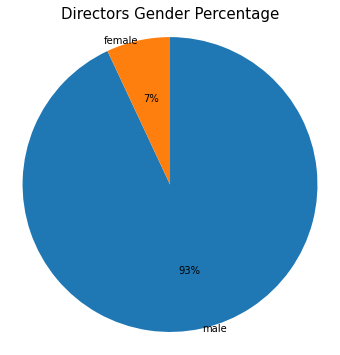

```python
# Pie plot of director gender
sorted_counts = movies_explore.director_gender.value_counts()
labels = sorted_counts.index

plt.figure(figsize=[6,6])
plt.pie(sorted_counts, labels=labels, startangle=90, counterclock=False, autopct='%1.00f%%', labeldistance= 1)
plt.axis('square')
plt.title('Directors Gender Percentage', pad=3, fontsize=15);
```

Whoa! The sample collected from TMDB shows that the average number of male directors are far bigger *about 93%* than the average number of female directors *7%*. This is an interesting social observation that we can elaborate on later. Now, let's move on to the next feature: `vote_average`.

```python
movies_explore.vote_average.describe()
```

```
count    9808.000000
mean        6.238163
std         1.115933
min         0.000000
25%         5.600000
50%         6.300000
75%         7.000000
max        10.000000
Name: vote_average, dtype: float64
```

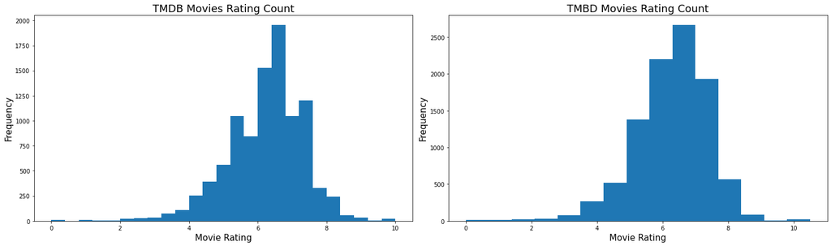

```python
# Histogram of Ratings
plt.figure(figsize=[20,6])

plt.subplot(1,2,1)
bins = np.arange(movies_explore.vote_average.min(), movies_explore.vote_average.max() + 0.4, 0.4)
plt.hist(movies_explore.vote_average, bins=bins)
plt.title('TMDB Movies Rating Count', fontsize=18)
plt.xlabel('Movie Rating', fontsize=15)
plt.ylabel('Frequency', fontsize=15)

plt.subplot(1,2,2)
bins = np.arange(movies_explore.vote_average.min(), movies_explore.vote_average.max() + 0.7, 0.7)
plt.hist(movies_explore.vote_average, bins=bins)
plt.title('TMBD Movies Rating Count', fontsize=18)
plt.xlabel('Movie Rating', fontsize=15)
plt.ylabel('Frequency', fontsize=15)

plt.tight_layout()
plt.show()
```

Looks like movie ratings are a bit skewed to the left with a tendency towards the center that it could make a semi normal distribution. This makes sense, but it's a must to note on credibility of rating, because unless the vote count is large enough, this rating isn't accountable.

Now, let's take a look on released `year` distribution.

```python
movies_explore.year.describe()
```

```
count    9808.000000
mean     1992.486847
std        21.221725
min      1874.000000
25%      1978.000000
50%      2000.500000
75%      2009.000000
max      2017.000000
Name: year, dtype: float64
```

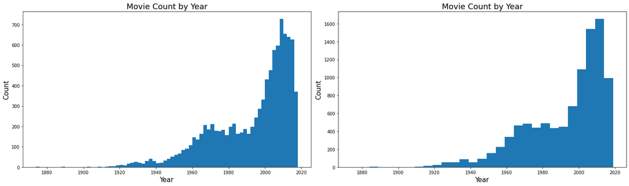

```python
# Histogram of Released Year
plt.figure(figsize=[20,6])

plt.subplot(1,2,1)
bins = np.arange(movies_explore.year.min(), movies_explore.year.max() + 2, 2)
plt.hist(movies_explore.year, bins=bins)
plt.title('Movie Count by Year', fontsize=18)
plt.xlabel('Year', fontsize=15)
plt.ylabel('Count', fontsize=15)

plt.subplot(1,2,2)
bins = np.arange(movies_explore.year.min(), movies_explore.year.max() + 5, 5)
plt.hist(movies_explore.year, bins=bins)
plt.title('Movie Count by Year', fontsize=18)
plt.xlabel('Year', fontsize=15)
plt.ylabel('Count', fontsize=15)

plt.tight_layout()
plt.show()
```

```python
movies_explore[movies_explore.year <  1900]
```

|  | genres | id | original_language | original_title | overview | popularity | poster_path | production_companies | production_countries | release_date | runtime | spoken_languages | title | vote_average | vote_count | cast | crew | year | director | director_gender |
| --- | --- | --- | --- | --- | --- | --- | --- | --- | --- | --- | --- | --- | --- | --- | --- | --- | --- | --- | --- | --- |
| 7972 | [{'id': 99, 'name': 'Documentary'}] | 96882 | xx | Accordion Player | The last remaining film of Le Prince's LPCCP T... | 0.212768 | /jAJT9hDfEDz3f4Uo4yqqVRBR5Yj.jpg | [{'name': 'Whitley Partners', 'id': 48026}] | [{'iso_3166_1': 'GB', 'name': 'United Kingdom'}] | 1888-01-01 | 1.0 | [{'iso_639_1': 'xx', 'name': 'No Language'}] | Accordion Player | 4.4 | 18.0 | [{'cast_id': 1, 'character': 'Himself', 'credi... | [{'credit_id': '52fe49c39251416c750d2a8b', 'de... | 1888 | Louis Aimé Augustin Le Prince | male |
| 7973 | [{'id': 99, 'name': 'Documentary'}] | 16464 | xx | Traffic Crossing Leeds Bridge | A film by Louis Aimé Augustin Le Prince, shot ... | 1.490420 | /tI7SfgAWbNLtby4whM9MxVve4IA.jpg | [{'name': 'Whitley Partners', 'id': 48026}] | [{'iso_3166_1': 'GB', 'name': 'United Kingdom'}] | 1888-10-15 | 1.0 | [{'iso_639_1': 'xx', 'name': 'No Language'}] | Traffic Crossing Leeds Bridge | 5.9 | 25.0 | [] | [{'credit_id': '52fe46d69251416c75085367', 'de... | 1888 | Louis Aimé Augustin Le Prince | male |
| 7974 | [{'id': 99, 'name': 'Documentary'}] | 315946 | xx | Passage de Venus | Photo sequence of the rare transit of Venus ov... | 0.480371 | /9jtgJphKW836gISyzdUKWnZ6yrB.jpg | [] | [{'iso_3166_1': 'FR', 'name': 'France'}] | 1874-12-09 | 1.0 | [{'iso_639_1': 'xx', 'name': 'No Language'}] | Passage of Venus | 6.0 | 19.0 | [] | [{'credit_id': '55325dc09251417ae30009c3', 'de... | 1874 | P.J.C. Janssen | male |

- It seems that years 2010 and 2011 were very rich in movie production since they hold the highest count.
- There is an outlier that may seem an inaccurate point of data at first, but actually it IS a real movie. In fact, it's the oldest film on IMDb and Letterboxd. *Passage of Venus*; *a documentary film, representing a series of photographs of the transit of the planet Venus across the Sun in 1874. They were purportedly taken in Japan by the French astronomer Jules Janssen and Brazilian engineer Francisco Antônio de Almeida.*
- As well as another 2 outliers: *Accordion Player* and *Traffic Crossing Leeds Bridge* both in 1888. The first is a silent film and the latter is another documentary film.

Now let's move on to another feature of interest: `original_language`.

```python
movies_explore.original_language.value_counts()
```

```
en    4923
fr    1139
it     523
de     500
ja     433
      ...
mk       1
iu       1
jv       1
af       1
bo       1
Name: original_language, Length: 64, dtype: int64
```

These code names may be understandable for some, but it IS vague for others. So before exploring this feature, I'll convert language codes to its original names.

#### Additional Cleaning

It also seems like the code `xx` means this is a silent movie with no spoken language. And seems like there are still some duplicates so let's eliminate them.

```python
# Firstly assign inaccurate code names correctly
movies_explore.loc[3977, 'original_language'] = 'fr'
movies_explore.original_language = movies_explore.original_language.replace(['cn'],'zh')
movies_explore.original_language = movies_explore.original_language.replace(['sh'],'sr')
movies_explore.original_language = movies_explore.original_language.replace(['xx'],'tw')
```

```python
movies_explore = movies_explore.drop_duplicates()
movies_explore.info()
```

```
<class 'pandas.core.frame.DataFrame'>
Int64Index: 9778 entries, 0 to 9807
Data columns (total 20 columns):
 #   Column                Non-Null Count  Dtype
---  ------                --------------  -----
 0   genres                9778 non-null   object
 1   id                    9778 non-null   int64
 2   original_language     9778 non-null   object
 3   original_title        9778 non-null   object
 4   overview              9778 non-null   object
 5   popularity            9778 non-null   float64
 6   poster_path           9778 non-null   object
 7   production_companies  9778 non-null   object
 8   production_countries  9778 non-null   object
 9   release_date          9778 non-null   datetime64[ns]
 10  runtime               9778 non-null   float64
 11  spoken_languages      9778 non-null   object
 12  title                 9778 non-null   object
 13  vote_average          9778 non-null   float64
 14  vote_count            9778 non-null   float64
 15  cast                  9778 non-null   object
 16  crew                  9778 non-null   object
 17  year                  9778 non-null   int64
 18  director              9778 non-null   object
 19  director_gender       9778 non-null   object
dtypes: datetime64[ns](1), float64(4), int64(2), object(13)
memory usage: 1.6+ MB
```

```python
# Convert codes to names
movies_explore.original_language = movies_explore.original_language.apply(lambda x: languages.get(alpha2=x).name)
```

```python
# Reassign silent movies to their accurate language: Silent
movies_explore.original_language = movies_explore.original_language.replace(['Twi'],'Silent')
```

```python
movies_explore.original_language.value_counts()
```

```
English                  4916
French                   1136
Italian                   523
German                    497
Japanese                  433
                         ...
Slovak                      1
Malay (macrolanguage)       1
Kannada                     1
Croatian                    1
Panjabi                     1
Name: original_language, Length: 62, dtype: int64
```

Everything looks great! Now let's create our visualization!

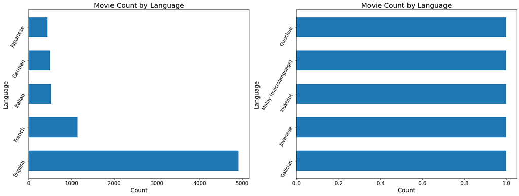

```python
# Bar plot for Movies Original Language
# First: the most common 5
plt.figure(figsize=[21,8])

plt.subplot(1,2,1)
top_languages = movies_explore.original_language.value_counts().head(5)
labels =[]
top_languages_count=[]

for label, count in enumerate(top_languages.index.tolist()):
    labels.append(label)
    top_languages_count.append(count)

plt.barh(top_languages_count, top_languages, height=0.6)

plt.title('Movie Count by Language', fontsize=20)
plt.xlabel('Count', fontsize=17)
plt.ylabel('Language', fontsize=17)
plt.yticks(fontsize= 15, rotation=60)
plt.xticks(fontsize= 15)


# Second: the least common 5
plt.subplot(1,2,2)
top_languages = movies_explore.original_language.value_counts().tail(5)
labels =[]
top_languages_count=[]

for label, count in enumerate(top_languages.index.tolist()):
    labels.append(label)
    top_languages_count.append(count)

plt.barh(top_languages_count, top_languages, height=0.6)

plt.title('Movie Count by Language', fontsize=20)
plt.xlabel('Count', fontsize=17)
plt.ylabel('Language', fontsize=17)
plt.yticks(fontsize= 14, rotation=60)
plt.xticks(fontsize= 15)

plt.tight_layout()
plt.show()
```

Even after deleting the movies produced by The US, the majority of movies are still in English, representing almost 5 thousand movies. While the second place falls far behind for about 1200 movies and goes to the French movies, the third to Italian, the fourth to German, and the fifth to Japanese movies.

This is really interesting, especially for diverse-culture lovers who would enjoy watching movies in these unpopular yet rich languages.

Now let's make fun displaying words of movies titles.

```python
title_corpus = ' '.join(movies_explore['title'])
original_corpus = ' '.join(movies_explore['original_title'])
```

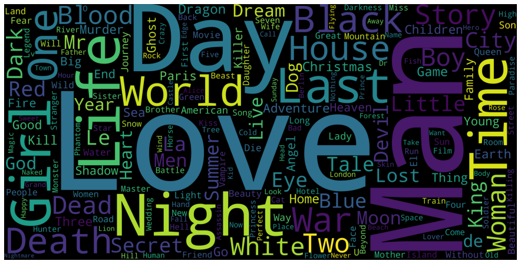

```python
# Create a wordcloud object for our translated movies' titles
title_wordcloud = WordCloud(stopwords=STOPWORDS, background_color='black', height=2000, width=4000).generate(title_corpus)
plt.figure(figsize=(20,8))
plt.imshow(title_wordcloud)
plt.axis('off')
# Save the image and show it
plt.savefig('MoviesTitles.png')
plt.show()
```

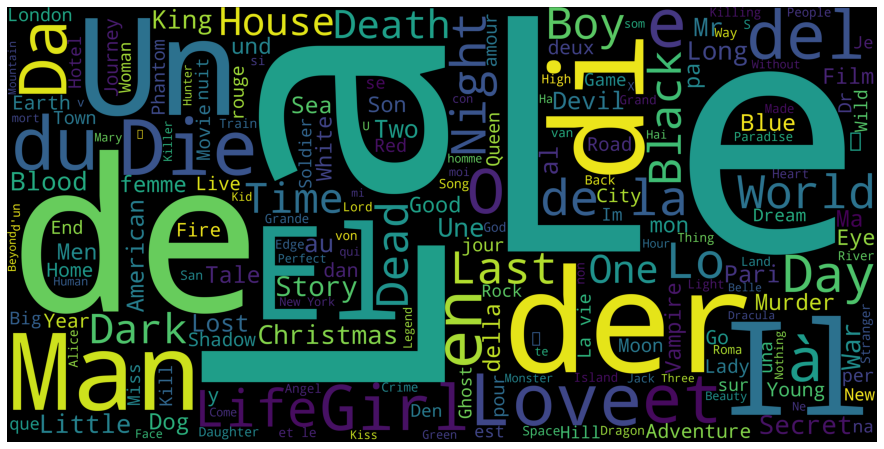

```python
# Create another wordcloud object for our original movies' titles
original_wordcloud = WordCloud(stopwords=STOPWORDS, background_color='black', height=2000, width=4000).generate(original_corpus)
plt.figure(figsize=(20,8))
plt.imshow(original_wordcloud)
plt.axis('off')
# Save the image and show it
plt.savefig('MoviesOriginalTitles.png')
plt.show()
```

Original titles looks good, and it would've made a better impression if languages articles were removed. But all in all, both images give us an indication of the common themes in movies.

- Love, girl, man, femme, boy, heart, kiss: drama and romance themes
- Death, god, lost, time, paradise, angel: existential themes
- Killer, murder, blood, devil, darkness: crime and horror themes
- Adventure, story, tale, dragon: fiction and adventure themes

It also seems that some movies were published by its original movie title because we can notice some French articles in the first titles image.

It's noteworthy that even with language diversity, some particular words are common in multiple languages, such as night (nuit), Death (mort), and Day (jour). This may be an indication of common culture similarities between for example The US, UK, and France.

This wordcloud inspired me to check movies with the highest numbers of spoken languages in them. To plot this, we'll need to convert the column of `spoken_languages` into a numeric variable first. Here we go!

```python
# Convert to numeric
movies_explore['spoken_languages'] = movies_explore['spoken_languages'].fillna('[]').apply(ast.literal_eval).apply(lambda x: len(x) if isinstance(x, list) else np.nan)
# Check if successfully convertes
movies_explore.spoken_languages.value_counts()
```

```
1    7169
2    1534
3     602
4     211
0     149
5      71
6      31
8       4
7       4
9       3
Name: spoken_languages, dtype: int64
```

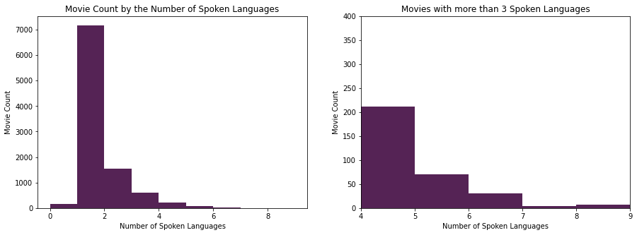

```python
# Bar plot for spoken languages
plt.figure(figsize=[15,5])

plt.subplot(1,2,1)
bins = np.arange(movies_explore.spoken_languages.min(), movies_explore.spoken_languages.max()+1, 1)
plt.hist(data=movies_explore, x='spoken_languages', bins=bins, color='#552355')
plt.title('Movie Count by the Number of Spoken Languages')
plt.xlabel('Number of Spoken Languages')
plt.ylabel('Movie Count');

# Histogram focusing on movies with more than 3 languages
plt.subplot(1,2,2)
bins = np.arange(movies_explore.spoken_languages.min(), movies_explore.spoken_languages.max()+1, 1)
plt.hist(data=movies_explore, x='spoken_languages', bins=bins, color='#552355')
plt.xlim((4,9))
plt.ylim((0,400))
plt.title('Movies with more than 3 Spoken Languages')
plt.xlabel('Number of Spoken Languages')
plt.ylabel('Movie Count');
```

Interesting! There are movies so multi-cultural that they have like 9 different languages spoken in them. This calls for a deeper investigation at the next part of analysis.

Now let's move on and take a look on the top 10 **directors** in our dataset.

```python
# Preview the top 10 directors
movies_explore.director.value_counts().head(10)
```

```
Werner Herzog               44
Jean-Luc Godard             40
Ingmar Bergman              36
Rainer Werner Fassbinder    30
Akira Kurosawa              28
Lucio Fulci                 27
Wim Wenders                 27
Luis Buñuel                 26
Alfred Hitchcock            24
Federico Fellini            23
Name: director, dtype: int64
```

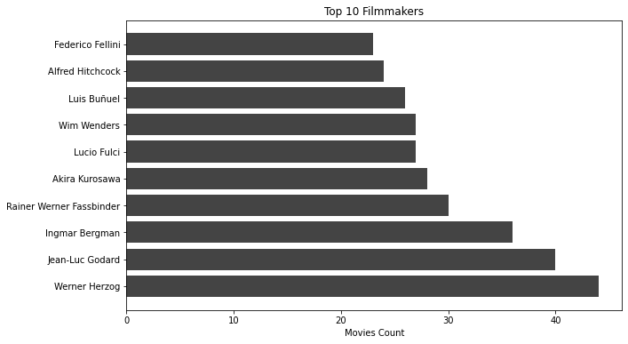

```python
# Bar plot top 10 directors
plt.figure(figsize=[10,6])
top_dir = movies_explore.director.value_counts().head(10).index
count = movies_explore.director.value_counts().head(10)

plt.barh(top_dir, count, color='#444444')

plt.title('Top 10 Filmmakers')
plt.xlabel('Movies Count');
```

The top filmmaker in terms of movies production is the German director *Herzog* with 44 movies. Comes after him the French director *Godard* with 40 movies, and in the third close place comes the Swedish *Bergman* with 36 movies. The rest of the top 10 directors are all contributing with an average of 25 films.

It's very interesting that:

- NINE out of the 10 top filmmakers aren't native English speakers.
- All of the most contributing filmmakers are men.

This shows that the most active and productive filmmakers aren't American nor English, so it's clear that there are many cinematic gems available for who can get out of hollywood box. It's also apparent from this graph and others that women aren't contributing in filmmaking as men, so we can't help but ask *why?*

That's all for our univariate analysis. No further cleaning is needed, nor transformation.

### 2.2. Bivariate Analysis

In this section, investigate relationships between pairs of variables in your data. I'm interested in:

- Taking a glance on all our features linear correlation and investigate more if something interesting appeared.
- Check the movies count for each language sorted by the director's gender.
- Check the relationship between the movie's director gender and other supporting features.
- Plot each one of these features (runtime, director gender, vote average) along with years.

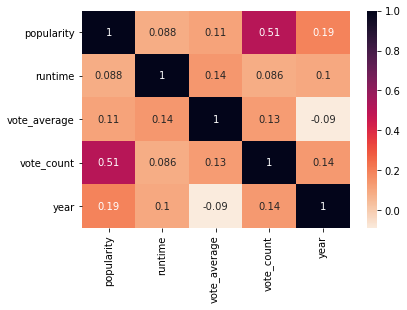

```python
# Create a heatmap for different numeric features
movie_features = movies_explore[['popularity', 'runtime', 'vote_average', 'vote_count', 'year']]

#ploting the heatmap for correlation
ax = sb.heatmap(movie_features.corr(), annot=True, cmap='rocket_r')
```

I expected that there will be some kind of correlation between **popularity** and **average vote**, but turns out there isn't. Good ratings and votes on a particular movie does not necessarily imply that the movie is popular, and vice versa. While there is an evidence for a moderate positive linear relationship between **popularity** and **vote count** which suggests that the more votes or ratings a movie has, the more popular it is, and vice versa. Which makes perfect sense.

Other than this, there is no apparent evidence for *linear* correlation among our other numeric features.

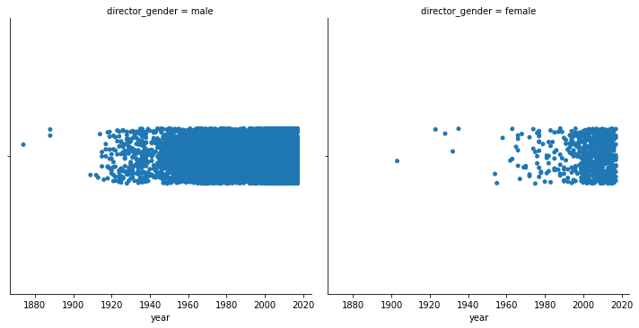

```python
# Check director's gender vs year
sb.catplot(x="year", hue="director_gender", col="director_gender", data=movies_explore, kind="strip", legend=True);
```

It's apparent that women are a minority in the filmmaking industry worldwide. But we can notice a shifting increase in 2000 and upward, which in history matches with the beginning of fruitful results from [the third wave of feminism](https://en.wikipedia.org/wiki/Third-wave_feminism). However, it's still quite low compared to male filmmakers. This may be explained by:

- Cultural reasons: places where women aren't empowered enough to direct a movie.
- Bias reasons: places where women are empowered yet men are favoured over them.
- Natural reasons

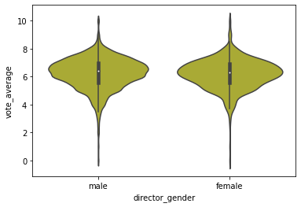

```python
# Check director's gender vs vote average
base_color= sb.color_palette()[8]
sb.violinplot(data=movies_explore, x='director_gender', y='vote_average', color=base_color);
```

Seems like the average ratings and votes is indifferent to the director's gender. This is *significant*, since it attests to the similarity for filmmaking average skills between women and men.

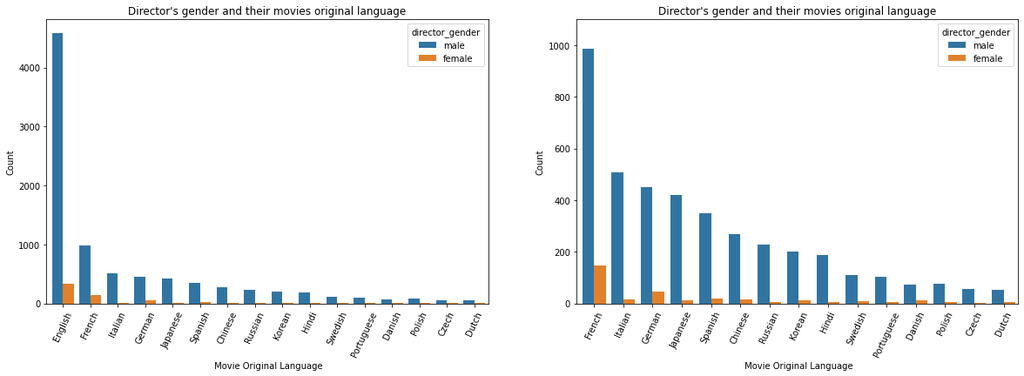

```python
# Check director's gender vs original movie language
plt.figure(figsize=[20,6])

plt.subplot(1,2,1)
sb.countplot(data=movies_explore, x='original_language', hue='director_gender', order = movies_explore['original_language'].value_counts().index)
plt.xlim((-0.60, 15.5))
plt.xticks(rotation=65)
plt.title("Director's gender and their movies original language")
plt.ylabel('Count')
plt.xlabel(' Movie Original Language');

# Try it once more but without English movies to avoid their monopoly over cinema:D
plt.subplot(1,2,2)
sb.countplot(data=movies_explore, x='original_language', hue='director_gender', order = movies_explore['original_language'].value_counts().index)
plt.xlim((0.4, 15.5))
plt.ylim((0, 1100))
plt.xticks(rotation=65)
plt.title("Director's gender and their movies original language")
plt.ylabel('Count')
plt.xlabel(' Movie Original Language');
```

Now let's check the progress of both **average vote** and **runtime** over years.

```python
movies_explore.runtime.describe()
```

```
count    9778.000000
mean      105.109225
std        34.761737
min         1.000000
25%        91.000000
50%       100.000000
75%       115.000000
max       931.000000
Name: runtime, dtype: float64
```

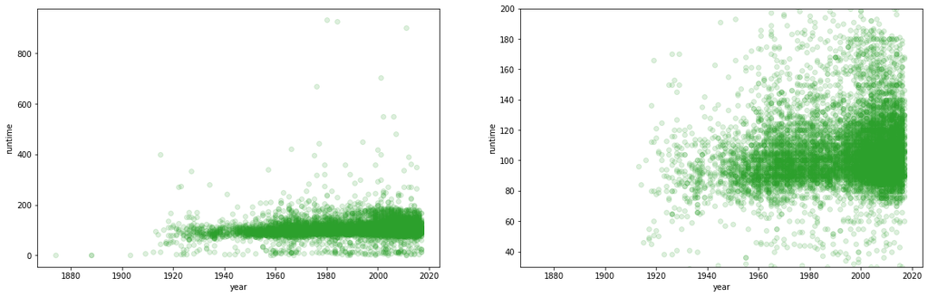

```python
# Plot a scatter showing movies runtime vs released years
# The first including outliers
plt.figure(figsize=[20,6])

plt.subplot(1,2,1)
base_color= sb.color_palette()[2]
sb.regplot(data=movies_explore, x='year', y='runtime', scatter_kws={'alpha':0.16}, fit_reg=False, color=base_color)

# The second focusing on the average
plt.subplot(1,2,2)
base_color= sb.color_palette()[2]
sb.regplot(data=movies_explore, x='year', y='runtime', scatter_kws={'alpha':0.16}, fit_reg=False, color=base_color)
plt.ylim((30, 200));
```

```python
movies_explore[movies_explore.runtime > 800]
```

|  | genres | id | original_language | original_title | overview | popularity | poster_path | production_companies | production_countries | release_date | runtime | spoken_languages | title | vote_average | vote_count | cast | crew | year | director | director_gender |
| --- | --- | --- | --- | --- | --- | --- | --- | --- | --- | --- | --- | --- | --- | --- | --- | --- | --- | --- | --- | --- |
| 3489 | [{'id': 18, 'name': 'Drama'}] | 45560 | German | Berlin Alexanderplatz | Berlin Alexanderplatz, originally broadcast in... | 2.255785 | /gMp5xe9DkWtrWQzjfuAJxt1tibe.jpg | [{'name': 'Bavaria Film', 'id': 1704}, {'name'... | [{'iso_3166_1': 'DE', 'name': 'Germany'}, {'is... | 1980-08-28 | 931.0 | [{'iso_639_1': 'de', 'name': 'Deutsch'}] | Berlin Alexanderplatz | 8.4 | 5.0 | [{'cast_id': 2, 'character': 'Franz Biberkopf'... | [{'credit_id': '5653d1dac3a36850fc001c27', 'de... | 1980 | Rainer Werner Fassbinder | male |
| 3529 | [{'id': 18, 'name': 'Drama'}, {'id': 36, 'name... | 67463 | German | Heimat: Eine deutsche Chronik | This epic tale of a family and their rural lif... | 0.016204 | /A6j8ZUpPzGclIGeSWjOQ74c6PO8.jpg | [] | [{'iso_3166_1': 'DE', 'name': 'Germany'}] | 1984-09-16 | 925.0 | [] | Heimat: A Chronicle of Germany | 9.0 | 1.0 | [{'cast_id': 1, 'character': 'Maria Simon', 'c... | [{'credit_id': '544fe328c3a368532b0024da', 'de... | 1984 | Edgar Reitz | male |
| 6638 | [{'id': 99, 'name': 'Documentary'}] | 125336 | English | The Story of Film: An Odyssey | The Story of Film: An Odyssey, written and dir... | 1.502510 | /21JcMfxZr0V7sDHQtaTbygL9FzQ.jpg | [] | [{'iso_3166_1': 'GB', 'name': 'United Kingdom'}] | 2011-09-03 | 900.0 | [{'iso_639_1': 'en', 'name': 'English'}] | The Story of Film: An Odyssey | 8.8 | 26.0 | [{'cast_id': 2, 'character': 'Narrator', 'cred... | [{'credit_id': '52fe4ac3c3a368484e1658d5', 'de... | 2011 | Mark Cousins | male |

Seems that the majority of movies runtime ranges from about 50 minutes to 140 minutes, when the longest runtime for the Germann movie [Berlin Alexanderplatz](https://letterboxd.com/film/berlin-alexanderplatz/) which is 931 minutes. Comes after it another German movie [Heimat](https://letterboxd.com/film/heimat-1984/) with 925 minutes, and finally [The Story of Film: An Odyssey](https://letterboxd.com/film/the-story-of-film-an-odyssey/) with 900 minutes. This indicates that the German are pioneers in long movies, especially that both of the mentioned movies were made in the 80s.

It's also very accurate to come across 1-minute films, as time is relative and isn't necessarily limited to a certain frame in cinema art.

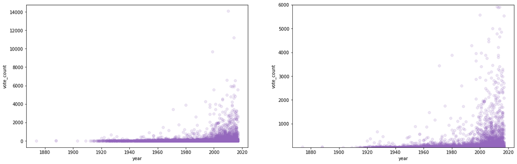

```python
# Plot a scatter showing movies runtime vs released years
# The first including outliers
plt.figure(figsize=[20,6])

plt.subplot(1,2,1)
base_color= sb.color_palette()[4]
sb.regplot(data=movies_explore, x='year', y='vote_count', scatter_kws={'alpha':0.16}, fit_reg=False, color=base_color)

# The second focusing on the average
plt.subplot(1,2,2)
base_color= sb.color_palette()[4]
sb.regplot(data=movies_explore, x='year', y='vote_count', scatter_kws={'alpha':0.16}, fit_reg=False, color=base_color)
plt.ylim((10, 6000));
```

```python
movies_explore.vote_count.describe()
```

```
count     9778.000000
mean       103.846492
std        421.853584
min          1.000000
25%          6.000000
50%         15.000000
75%         47.000000
max      14075.000000
Name: vote_count, dtype: float64
```

```python
movies_explore[movies_explore.vote_count >= 3000].groupby('vote_count')['year'].mean()
```

```
vote_count
3017.0     2015.0
3031.0     2012.0
3122.0     2006.0
3124.0     2015.0
3181.0     2008.0
3213.0     2016.0
3232.0     2014.0
3290.0     2013.0
3294.0     2016.0
3403.0     2007.5
3432.0     1971.0
3451.0     2009.0
3643.0     1997.0
3759.0     2005.0
3787.0     2013.0
3885.0     2013.0
3889.0     2004.0
3890.0     1980.0
3962.0     1997.0
3968.0     2001.0
4215.0     2013.0
4293.0     1994.0
4455.0     2006.0
4562.0     2006.0
4644.0     2014.0
4777.0     2012.0
4862.0     2015.0
4979.0     2014.0
4994.0     2009.0
5530.0     2017.0
5566.0     2000.0
5879.0     2013.0
5895.0     2014.0
5912.0     2012.0
6048.0     2014.0
6558.0     2015.0
6598.0     2009.0
9678.0     1999.0
11187.0    2014.0
14075.0    2010.0
Name: year, dtype: float64
```

```python
movies_explore[movies_explore.vote_count == 3890]
```

|  | genres | id | original_language | original_title | overview | popularity | poster_path | production_companies | production_countries | release_date | runtime | spoken_languages | title | vote_average | vote_count | cast | crew | year | director | director_gender |
| --- | --- | --- | --- | --- | --- | --- | --- | --- | --- | --- | --- | --- | --- | --- | --- | --- | --- | --- | --- | --- |
| 258 | [{'id': 27, 'name': 'Horror'}, {'id': 53, 'nam... | 694 | English | The Shining | Jack Torrance accepts a caretaker job at the O... | 19.611589 | /9fgh3Ns1iRzlQNYuJyK0ARQZU7w.jpg | [{'name': 'Hawk Films', 'id': 88}, {'name': 'W... | [{'iso_3166_1': 'US', 'name': 'United States o... | 1980-05-22 | 144.0 | [{'iso_639_1': 'en', 'name': 'English'}] | The Shining | 8.1 | 3890.0 | [{'cast_id': 18, 'character': 'Jack Torrance',... | [{'credit_id': '52fe426bc3a36847f801d39b', 'de... | 1980 | Stanley Kubrick | male |

This shows that many cinema lovers focus on rating recent movies, starting from 2000 to now. There are a few exceptions such as [The Shining](https://letterboxd.com/film/the-shining/) with about 4000 votes albeit produced in 1980.

It's very important to make a statement here on the credibility of ratings. The more vote count, the more voting credibility. That's why I didn't focus much in this analysis on ratings in determining the quality of a movie or any of its cinematic aspects really, nor it would've been of important with cultural investigations since voters data isn't available.

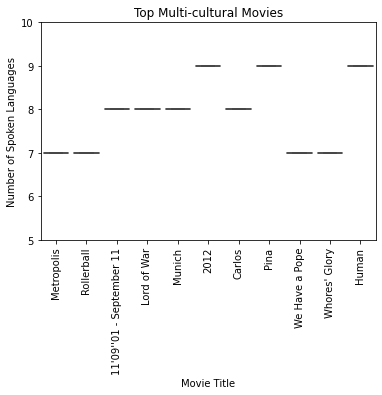

```python
# Create a dataframe of multi cultrual movies
multiculture = movies_explore[movies_explore.spoken_languages > 6]
# Plot
sb.boxplot(data=multiculture, x='title', y='spoken_languages')
plt.ylim((5,10))
plt.xticks(rotation=90)
plt.title('Top Multi-cultural Movies')
plt.xlabel('Movie Title')
plt.ylabel('Number of Spoken Languages');
```

The top 3 multi-cultural movies are:

- [Pina](https://letterboxd.com/film/pina/) by Wim Wenders
- [Human](https://letterboxd.com/film/human-2015/) by Yann Arthus-Bertrand
- [2012](https://letterboxd.com/film/2012/) by Roland Emmerich

We can notice that one of the top 3 *Pina* is directed by one of the top 10 directors *Wenders*. This list of movies is highly recommended for cinema lovers and people who are interested in many cultures as they present snapshots of divesity.

It's also important to note that when a movie has many languages, it doesn't necessarily indicate a movie of quality.

### Bivariate Analysis Conclusuions

In this section, the following two-way relationships were investigated and it appeared that:

Interesting positive moderate linear relationship was accidentally found between vote count and popularity, meaning that the more votes or ratings a movie has, the more popular it is on a moderate scale, and vice versa. Which makes perfect sense. While on the other hand, no relationship was found between average rating and popularity, meaning that good ratings on a particular movie does not necessarily imply that this movie is popular, and vice versa.

Now we can move on to the last step of our exploratory analysis; the multivariate analysis.

### 2.3. Multivariate Analysis

This is the part where plots of three or more variables to investigate your data even further.

Let's first create a faceted plot connecting two of our main features of interest *Original Language* and *Director Gender* to *Vote Count* across years, in order to see how insightful the interactions between them are over time.

```python
# Facet plot of director gender, original language, vote count over time
g = sb.FacetGrid(data=movies_explore, col='director_gender', row= 'original_language', margin_titles = True)
g.map(plt.scatter, 'year', 'vote_count');
```

[figure not shown]

Very informative! In spite of this plot having 62 rows for 2 columns, it's still quite understandable. It's interesting that:

- The gap between women and men is common in different cultures, with it being the smallest in the French culture.
- No silent movies directed by women were found in our dataset.
- The highest count of votes is mainly for English speaking movies, and after it the French, with a few outliers in languages like Korean, Japanese and Spanish.
- Some cultures other than English and French began creating movies before 1950, like Hindi, Swedish, Russian and Japanese.

These findings align with our previous conclusions, showing that movie production increased across years reaching its peak around 2010. While female filmmakers still need more support especially from the local not universal cultures. It's also logical using *vote count* instead of vote average here for credibility reasons.

There weren't any surprising relationships. But this project is a starting point to elaborate more on this interesting topic in a more directed manner for the future.

Now before conclusions, let'd save our cleaned dataframe in a CSV file.

```python
# Save the dataframe
movies_explore.to_csv('movies_clean.csv', index=False)
```

## Conclusions

This exploratory analysis investigated [The Movies Dataset](https://www.kaggle.com/rounakbanik/the-movies-dataset) that contains the metadata for all 45,000 movies listed in the Full MovieLens Dataset. After cleaning the data and eliminating unnecessary features, the number of movies dropped to about 9800. This number of movies was analyzed visually, focusing on the **social** and **cultural** patterns and relationships. Mainly *Filmmaker Gender*, *Film's Original Language*, and *Film's Number of Spoken Languages*. Besides, another side features like *Film's Runtime*, *Film's Vote Count*, and *Filmmakers*.

I tried to tackle this dataset with care, respecting filmmaking and cinema, and trying my best not to tackle it in a superficial manner. So, after doing the data wrangling and exploratory visualizations, the following important *descriptive* insights were found:

#### General Conclusuions:

- The higher rating a film has doesn't necessarily mean the more popular or acclaimed. Even with the *enough* amount of voters, there isn't a proven relationship between rating and popularity in cinema.
- Many cultures are interested in cinema, but they lack popularity due to the barrier of language.
- There's a trend among people leaning towards recent movies, starting from 2000 to now, with a few exceptions.

#### Gender-study-related Conclusuions:

- There's a wide gender gap between women and men filmmakers contributing in the industry. Reasons aren't clear which gives the space for another elaboration and usage of regression analysis.
- Women only began to direct films later than men, and only increased starting 2000.
- Films' ratings for both men and women have almost the same average, close minimum and maximum points, suggesting that the lack of women in film industry isn't due to their lack of skill or talent.

### Recommendations:

For any future additions to this project, there are some kind of tips here.

- Create a logistic regression model focusing on director's gender and trying to understand its relationship with other features more.
- There are plenty of data that weren't used like genre, crew and poster. And they can be pretty useful on a larger scale.
- Adding movement as an encoding to represent time and show the evolution of cinema history would be interesting.
- Recommendation systems can be built for this dataset based on rating, genre and cultural diversity.